# Association Rule (연관 규칙 분석)

B team(김주희, 김태규, 임광윤, 천희정, 김동우)

2025-01-22

## 소개

**arules** 패키지를 사용하여 연관 규칙 분석을 진행.

### 라이브러리

```r
# 필요한 라이브러리 설치 및 로드
if (!requireNamespace("arules", quietly = TRUE)) {
  install.packages("arules")
}
library(arules)
```

## Q1: 데이터셋을 읽고 이를 트랜잭션 형태로 변환

```r
# 데이터셋 로드
products <- readRDS("C:/Users/취업하자/Desktop/MBA/겨울계절학기/데이터과학의기초/Dataset_HW/8. Association rule/products.rds")

# 데이터 구조 확인
str(products)
```

```
## List of 131209
##  $ : chr [1:8] "Bulgarian Yogurt" "Organic 4% Milk Fat Whole Milk Cottage Cheese" "Organic Celery Hearts" "Cucumber Kirby" ...
##  $ : chr [1:8] "Grated Pecorino Romano Cheese" "Spring Water" "Organic Half & Half" "Super Greens Salad" ...
##  $ : chr [1:9] "Shelled Pistachios" "Organic Biologique Limes" "Organic Raw Unfiltered Apple Cider Vinegar" "Organic Baby Arugula" ...
##  $ : chr [1:7] "Roasted Turkey" "Organic Cucumber" "Organic Grape Tomatoes" "Organic Pomegranate Kernels" ...
##  $ : chr [1:49] "Natural Spring Water" "Organic Orange Juice With Calcium & Vitamin D" "Whole Milk Greek Blended Vanilla Bean Yogurt" "Bag of Organic Bananas" ...
##  $ : chr [1:11] "Fresh Cauliflower" "I Heart Baby Kale" "Sea Salt Baked Potato Chips" "Marinara Pasta Sauce" ...
##  $ : chr [1:17] "Asian Chopped Salad with Dressing" "XL Emerald White Seedless Grapes" "Bag of Organic Bananas" "BBQ Ranch Chopped Salad" ...
##  $ : chr [1:5] "Natural Artisan Water" "Okra" "Organic Yellow Peaches" "Black Plum" ...
##  $ : chr [1:13] "Clementines, Bag" "Banana" "Kids! Chewables Probiotic Tablets Natural Bursting Berry Flavor" "Vitamin D Whole Milk" ...
##  $ : chr [1:11] "Pure Irish Butter" "Pure Almond Unsweetened Original Almond Milk" "Natural Chicken & Sage Breakfast Sausage" "Uncured Hickory Smoked Sunday Bacon" ...
##  $ : chr [1:8] "Shredded Mexican Blend Cheese" "Clementines" "Fat Free Skim Milk" "Red Delicious Apples" ...
##  $ : chr [1:9] "Chorizo Pork" "Petite Peas" "Max Gel Clog Remover" "Green Beans" ...
##  $ : chr [1:8] "Organic Whole Milk with DHA Omega-3" "Banana" "Unsweetened Original Almond Breeze Almond Milk" "Baby Wipes" ...
##  $ : chr [1:17] "Organic Strawberries" "Uncured Genoa Salami" "Organic Baby Carrots" "Gluten Free Organic Taco Sliders Corn Tortillas" ...
```

[output cut: 86 more lines]

```r
# 트랜잭션 형태로 변환
products.trans <- as(products, "transactions")

# 트랜잭션 요약
summary(products.trans)
```

```
## transactions as itemMatrix in sparse format with
##  131209 rows (elements/itemsets/transactions) and
##  39123 columns (items) and a density of 0.0002697329
##
## most frequent items:
##                 Banana Bag of Organic Bananas   Organic Strawberries
##                  18726                  15480                  10894
##   Organic Baby Spinach            Large Lemon                (Other)
##                   9784                   8135                1321598
##
## element (itemset/transaction) length distribution:
## sizes
##    1    2    3    4    5    6    7    8    9   10   11   12   13   14   15   16
## 6845 7368 8033 8218 8895 8708 8541 7983 7217 6553 6034 5383 4843 4394 3831 3522
##   17   18   19   20   21   22   23   24   25   26   27   28   29   30   31   32
## 3108 2719 2473 2102 1857 1681 1462 1292 1079  986  860  679  634  553  446  403
##   33   34   35   36   37   38   39   40   41   42   43   44   45   46   47   48
##  346  315  280  210  193  178  142   99   90   88   75   79   64   48   49   32
##   49   50   51   52   53   54   55   56   57   58   59   60   61   62   63   64
##   26   31   24   23   18   15   12   10    6    5    4    8    3    3    5    4
##   65   66   67   68   70   72   74   75   76   77   80
##    3    2    1    2    4    2    2    1    2    1    2
##
##    Min. 1st Qu.  Median    Mean 3rd Qu.    Max.
##    1.00    5.00    9.00   10.55   14.00   80.00
##
## includes extended item information - examples:
##                         labels
## 1            #2 Coffee Filters
## 2 #2 Cone White Coffee Filters
## 3        #2 Mechanical Pencils
```

### 트랜잭션 데이터 요약

데이터가 131,209개의 트랜잭션(rows)과 39,123개의 아이템(columns)으로 구성되어 있음.

가장 빈번하게 등장하는 아이템: Banana와 Bag of Organic Bananas -> 이는 데이터를 통해 구매 트렌드가 Banana 중심으로 이루어진다는 것을 시사합니다.

### 시각화: 트랜잭션 데이터 요약

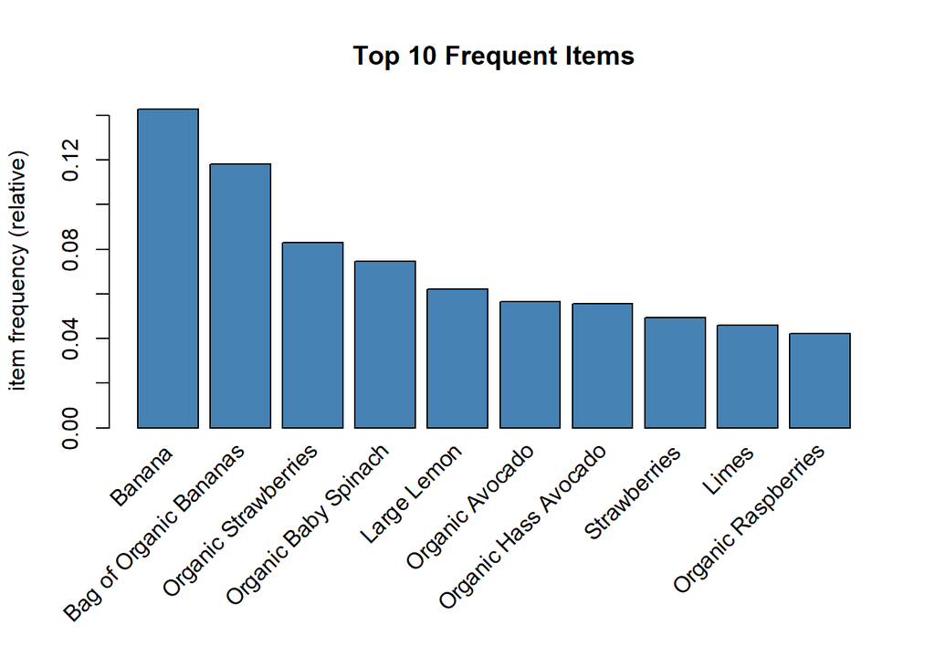

## Q2: 트랜잭션 수와 아이템 수를 확인하고, 첫 3개의 아이템을 표시

```r
# 트랜잭션 및 아이템 수
cat("트랜잭션 수:", length(products.trans), "\n")
```

```
## 트랜잭션 수: 131209
```

```r
cat("아이템 수:", length(itemLabels(products.trans)), "\n")
```

```
## 아이템 수: 39123
```

```r
# 첫 3개의 아이템
cat("첫 3개의 아이템:\n", itemLabels(products.trans)[1:3], "\n")
```

```
## 첫 3개의 아이템:
##  #2 Coffee Filters #2 Cone White Coffee Filters #2 Mechanical Pencils
```

### 분석 결과

트랜잭션 수는 131,209개, 아이템 수는 39,123개. 첫 번째로 등장하는 3개의 아이템은 Coffee Filters / Cone White Coffee Filters / Mechanical Pencils 입니다.

## Q3: apriori 알고리즘을 최소 지지도(support) 0.002와 최소 신뢰도(confidence) 0.25로 설정하여 실행. 규칙의 최대 길이는 2로 설정.

```r
# Apriori 실행 (지지도 0.002, 신뢰도 0.25)
rules <- apriori(
  products.trans,
  parameter = list(
    supp = 0.002,
    conf = 0.25,
    target = "rules",
    maxlen = 2
  )
)
```

```
## Apriori
##
## Parameter specification:
##  confidence minval smax arem  aval originalSupport maxtime support minlen
##        0.25    0.1    1 none FALSE            TRUE       5   0.002      1
##  maxlen target  ext
##       2  rules TRUE
##
## Algorithmic control:
##  filter tree heap memopt load sort verbose
##     0.1 TRUE TRUE  FALSE TRUE    2    TRUE
##
## Absolute minimum support count: 262
##
## set item appearances ...[0 item(s)] done [0.00s].
## set transactions ...[39123 item(s), 131209 transaction(s)] done [1.24s].
## sorting and recoding items ... [848 item(s)] done [0.04s].
## creating transaction tree ... done [0.11s].
## checking subsets of size 1 2
```

```
##  done [0.02s].
## writing ... [83 rule(s)] done [0.00s].
## creating S4 object  ... done [0.02s].
```

```r
# 생성된 규칙 요약
summary(rules)
```

```
## set of 83 rules
##
## rule length distribution (lhs + rhs):sizes
##  2
## 83
##
##    Min. 1st Qu.  Median    Mean 3rd Qu.    Max.
##       2       2       2       2       2       2
##
## summary of quality measures:
##     support           confidence        coverage             lift
##  Min.   :0.002004   Min.   :0.2502   Min.   :0.005564   Min.   : 1.831
##  1st Qu.:0.002698   1st Qu.:0.2695   1st Qu.:0.009271   1st Qu.: 2.071
##  Median :0.003925   Median :0.2856   Median :0.014328   Median : 2.330
##  Mean   :0.005381   Mean   :0.2921   Mean   :0.018442   Mean   : 3.192
##  3rd Qu.:0.005918   3rd Qu.:0.3065   3rd Qu.:0.020376   3rd Qu.: 2.833
##  Max.   :0.023428   Max.   :0.3861   Max.   :0.083028   Max.   :23.906
##      count
##  Min.   : 263.0
##  1st Qu.: 354.0
##  Median : 515.0
##  Mean   : 706.1
##  3rd Qu.: 776.5
##  Max.   :3074.0
##
## mining info:
##            data ntransactions support confidence
##  products.trans        131209   0.002       0.25
##                                                                                                       call
##  apriori(data = products.trans, parameter = list(supp = 0.002, conf = 0.25, target = "rules", maxlen = 2))
```

```r
# 상위 10개 규칙 확인
inspect(head(rules, 10))
```

```
##      lhs                                                        rhs                          support confidence    coverage      lift count
## [1]  {Clementines}                                           => {Bag of Organic Bananas} 0.002598907  0.2524056 0.010296550  2.139399   341
## [2]  {Blackberries}                                          => {Raspberries}            0.002248321  0.2739090 0.008208278 10.960453   295
## [3]  {Blackberries}                                          => {Strawberries}           0.002194971  0.2674095 0.008208278  5.402915   288
## [4]  {Organic Large Green Asparagus}                         => {Bag of Organic Bananas} 0.002004436  0.3602740 0.005563643  3.053694   263
## [5]  {Gala Apples}                                           => {Banana}                 0.002804686  0.3837331 0.007308950  2.688734   368
## [6]  {Total 0% Greek Yogurt}                                 => {Banana}                 0.002202593  0.2762906 0.007972014  1.935908   289
## [7]  {Organic Hothouse Cucumbers}                            => {Bag of Organic Bananas} 0.002019679  0.2861771 0.007057443  2.425647   265
## [8]  {Total 2% with Strawberry Lowfat Greek Strained Yogurt} => {Banana}                 0.002225457  0.3001028 0.007415650  2.102755   292
## [9]  {Organic Bartlett Pear}                                 => {Organic Strawberries}   0.002057786  0.2755102 0.007469000  3.318287   270
## [10] {Organic Bartlett Pear}                                 => {Bag of Organic Bananas} 0.002515071  0.3367347 0.007469000  2.854175   330
```

### 분석 결과

Apriori 알고리즘을 통해 83개의 규칙이 생성됨.

## Q4: 중복 규칙 제거

```r
# 중복 규칙 식별 및 제거
redundant <- is.redundant(rules)
rules_pruned <- rules[!redundant]

# 규칙 개수 확인
cat("총 규칙 수 (제거 전):", length(rules), "\n")
```

```
## 총 규칙 수 (제거 전): 83
```

```r
cat("중복 규칙 수:", sum(redundant), "\n")
```

```
## 중복 규칙 수: 0
```

```r
cat("중복 제거 후 규칙 수:", length(rules_pruned), "\n")
```

```
## 중복 제거 후 규칙 수: 83
```

```r
# 상위 10개 규칙 확인
inspect(head(rules_pruned, 10))
```

```
##      lhs                                                        rhs                          support confidence    coverage      lift count
## [1]  {Clementines}                                           => {Bag of Organic Bananas} 0.002598907  0.2524056 0.010296550  2.139399   341
## [2]  {Blackberries}                                          => {Raspberries}            0.002248321  0.2739090 0.008208278 10.960453   295
## [3]  {Blackberries}                                          => {Strawberries}           0.002194971  0.2674095 0.008208278  5.402915   288
## [4]  {Organic Large Green Asparagus}                         => {Bag of Organic Bananas} 0.002004436  0.3602740 0.005563643  3.053694   263
## [5]  {Gala Apples}                                           => {Banana}                 0.002804686  0.3837331 0.007308950  2.688734   368
## [6]  {Total 0% Greek Yogurt}                                 => {Banana}                 0.002202593  0.2762906 0.007972014  1.935908   289
## [7]  {Organic Hothouse Cucumbers}                            => {Bag of Organic Bananas} 0.002019679  0.2861771 0.007057443  2.425647   265
## [8]  {Total 2% with Strawberry Lowfat Greek Strained Yogurt} => {Banana}                 0.002225457  0.3001028 0.007415650  2.102755   292
## [9]  {Organic Bartlett Pear}                                 => {Organic Strawberries}   0.002057786  0.2755102 0.007469000  3.318287   270
## [10] {Organic Bartlett Pear}                                 => {Bag of Organic Bananas} 0.002515071  0.3367347 0.007469000  2.854175   330
```

### 분석 결과

중복 규칙 제거 후에도 83개의 규칙이 유지됨. 중복된 규칙이 생성되지 않았음을 의미함.

## Q5: Lift 기준 상위 규칙

```r
# Lift 기준으로 정렬 후 상위 10개 규칙 출력
rules_sorted <- sort(rules_pruned, by = "lift")
inspect(head(rules_sorted, 10))
```

```
##      lhs                       rhs                          support
## [1]  {Yellow Bell Pepper}   => {Orange Bell Pepper}         0.003018086
## [2]  {Organic Bell Pepper}  => {Organic Red Bell Pepper}    0.002134000
## [3]  {Blackberries}         => {Raspberries}                0.002248321
## [4]  {Lime Sparkling Water} => {Sparkling Water Grapefruit} 0.003848821
## [5]  {Bunched Cilantro}     => {Limes}                      0.004252757
## [6]  {Jalapeno Peppers}     => {Limes}                      0.004168921
## [7]  {Organic Cilantro}     => {Limes}                      0.007674778
## [8]  {Blackberries}         => {Strawberries}               0.002194971
## [9]  {Limes}                => {Large Lemon}                0.012156178
## [10] {Organic Raspberries}  => {Organic Strawberries}       0.012727785
##      confidence coverage    lift      count
## [1]  0.3396226  0.008886586 23.906409  396
## [2]  0.2969247  0.007187007 16.280482  280
## [3]  0.2739090  0.008208278 10.960453  295
## [4]  0.2568667  0.014983728 10.033709  505
## [5]  0.2906250  0.014633143  6.320672  558
## [6]  0.2880463  0.014473093  6.264590  547
## [7]  0.2855927  0.026873157  6.211228 1007
## [8]  0.2674095  0.008208278  5.402915  288
## [9]  0.2643792  0.045980078  4.264159 1595
## [10] 0.3011179  0.042268442  3.626710 1670
```

### 시각화: Lift 기준 상위 규칙

[interactive chart not shown]

### 분석 결과

높은 lift 값을 가진 규칙은 아이템 간의 강한 연관성을 나타냄. 예) Yellow Bell Pepper와 Orange Bell Pepper의 lift 값은 23.9로 매우 강한 연관성을 가지고 있음. 고객이 한 아이템을 구매할 때 다른 아이템도 구매할 가능성이 높음을 의미함함.

## Q6: “Banana”와 연관된 아이템

```r
# Banana 관련 규칙 생성
banana_rules <- apriori(
  products.trans,
  parameter = list(
    supp = 0.001,
    conf = 0.1,
    target = "rules",
    maxlen = 2
  ),
  appearance = list(
    lhs = "Banana",
    default = "rhs"
  )
)
```

```
## Apriori
##
## Parameter specification:
##  confidence minval smax arem  aval originalSupport maxtime support minlen
##         0.1    0.1    1 none FALSE            TRUE       5   0.001      1
##  maxlen target  ext
##       2  rules TRUE
##
## Algorithmic control:
##  filter tree heap memopt load sort verbose
##     0.1 TRUE TRUE  FALSE TRUE    2    TRUE
##
## Absolute minimum support count: 131
##
## set item appearances ...[1 item(s)] done [0.00s].
## set transactions ...[39123 item(s), 131209 transaction(s)] done [1.07s].
## sorting and recoding items ... [1865 item(s)] done [0.03s].
## creating transaction tree ... done [0.10s].
## checking subsets of size 1 2
```

```
##  done [0.27s].
## writing ... [6 rule(s)] done [0.00s].
## creating S4 object  ... done [0.02s].
```

```r
# Banana 규칙 요약
summary(banana_rules)
```

```
## set of 6 rules
##
## rule length distribution (lhs + rhs):sizes
## 1 2
## 1 5
##
##    Min. 1st Qu.  Median    Mean 3rd Qu.    Max.
##   1.000   2.000   2.000   1.833   2.000   2.000
##
## summary of quality measures:
##     support          confidence        coverage           lift
##  Min.   :0.01485   Min.   :0.1040   Min.   :0.1427   Min.   :1.000
##  1st Qu.:0.01554   1st Qu.:0.1089   1st Qu.:0.1427   1st Qu.:1.407
##  Median :0.01651   Median :0.1157   Median :0.1427   Median :1.646
##  Mean   :0.03300   Mean   :0.1131   Mean   :0.2856   Mean   :1.648
##  3rd Qu.:0.01681   3rd Qu.:0.1175   3rd Qu.:0.1427   3rd Qu.:2.036
##  Max.   :0.11798   Max.   :0.1183   Max.   :1.0000   Max.   :2.102
##      count
##  Min.   : 1948
##  1st Qu.: 2040
##  Median : 2166
##  Mean   : 4329
##  3rd Qu.: 2206
##  Max.   :15480
##
## mining info:
##            data ntransactions support confidence
##  products.trans        131209   0.001        0.1
##                                                                                                                                                          call
##  apriori(data = products.trans, parameter = list(supp = 0.001, conf = 0.1, target = "rules", maxlen = 2), appearance = list(lhs = "Banana", default = "rhs"))
```

```r
# 상위 10개 규칙 확인
inspect(head(sort(banana_rules, by = "confidence"), 10))
```

```
##     lhs         rhs                      support    confidence coverage
## [1] {Banana} => {Organic Avocado}        0.01688909 0.1183381  0.1427189
## [2] {}       => {Bag of Organic Bananas} 0.11797971 0.1179797  1.0000000
## [3] {Banana} => {Organic Strawberries}   0.01656899 0.1160953  0.1427189
## [4] {Banana} => {Large Lemon}            0.01644704 0.1152408  0.1427189
## [5] {Banana} => {Organic Baby Spinach}   0.01524286 0.1068034  0.1427189
## [6] {Banana} => {Strawberries}           0.01484654 0.1040265  0.1427189
##     lift     count
## [1] 2.095698  2216
## [2] 1.000000 15480
## [3] 1.398269  2174
## [4] 1.858714  2158
## [5] 1.432294  2000
## [6] 2.101819  1948
```

### 분석 결과

“Banana”를 구매한 고객은 주로 Organic Avocado(신뢰도 0.1183381)와 Organic Strawberries(신뢰도 0.1160953)를 함께 구매하는 경향이 있습니다.